# Essentials of Programming Languages.Friedman2008.3e

The specification for diff-exp shows how we specify sequential behavior.

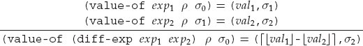

Here we evaluate *exp*<sub>1</sub> starting with the store in state *σ*<sub>0</sub>. *exp*<sub>1</sub> returns value *val*<sub>1</sub>, but it might also have some effects that leave the store in state *σ*<sub>1</sub>. We then evaluate *exp*<sub>2</sub> starting with the store in the state that *exp*<sub>1</sub> left it, namely *σ*<sub>1</sub>. *exp*<sub>2</sub> similarly returns a value *val*<sub>2</sub> and leaves the store in state *σ*<sub>2</sub>. Then the entire expression returns *val*<sub>1</sub> − *val*<sub>2</sub> without further effect on the store, so it leaves the store in state *σ*<sub>2</sub>.

Let’s try a conditional.

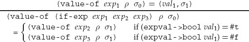

Starting in state *σ*<sub>0</sub>, an if-exp evaluates its test expression *exp*<sub>1</sub>, returning the value *val*<sub>1</sub> and leaving the store in state *σ*<sub>1</sub>. The result of the entire expression is then either the result of *exp*<sub>2</sub> or *exp*<sub>3</sub>, each evaluated in the current environment *ρ* and in the state *σ*<sub>1</sub> in which *exp*<sub>1</sub> left the store.

Exercise 4.2 [⋆] Write down the specification for a zero?-exp.

Exercise 4.3 [⋆] Write down the specification for a call-exp.

Exercise 4.4 [⋆⋆] Write down the specification for a begin expresssion.

*Expression* ::= begin *Expression* {; *Expression*}<sup>∗</sup> end

A begin expression may contain one or more subexpressions separated by semicolons. These are evaluated in order and the value of the last is returned.

Exercise 4.5 [⋆⋆] Write down the specification for list (exercise 3.10).

**4.2.2 Specifying Operations on Explicit References**

In EXPLICIT-REFS, we have three new operations that must be specified: newref, deref, and setref. These are given by the grammar

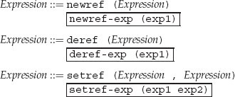

We can specify the behavior of these operations as follows.

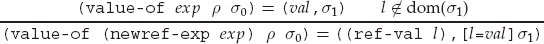

This rule says that newref-exp evaluates its operand. It extends the resulting store by allocating a new location *l* and puts the value *val* of its argument in that location. Then it returns a reference to a location *l* that is new. This means that it is not already in the domain of *σ*<sub>1</sub>.

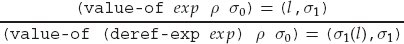

This rule says that a deref-exp evaluates its operand, leaving the store in state *σ*<sub>1</sub>. The value of that argument should be a reference to a location *l*. The deref-exp then returns the contents of *l* in *σ*<sub>1</sub>, without any further change to the store.

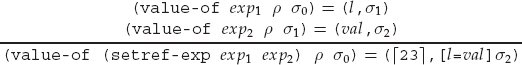

This rule says that a setref-exp evaluates its operands from left to right. The value of the first operand must be a reference to a location *l*. The setref-exp then updates the resulting store by putting the value *val* of the second argument in location *l*. What should a setref-exp return? It could return anything. To emphasize the arbitrary nature of this choice, we have specified that it returns 23. Because we are not interested in the value returned by a setref-exp, we say that this expression is executed *for effect*, rather than for its value.

Exercise 4.6 [⋆] Modify the rule given above so that a setref-exp returns the value of the right-hand side.

Exercise 4.7 [⋆] Modify the rule given above so that a setref-exp returns the old contents of the location.

**4.2.3 Implementation**

The specification language we have used so far makes it easy to describe the desired behavior of effectful computations, but it does not embody a key fact about the store: a reference ultimately refers to a real location in a memory that exists in the real world. Since we have only one real world, our program can only keep track of one state *σ* of the store.

In our implementations, we take advantage of this fact by modeling the store using Scheme’s own store. Thus we model an effect as a Scheme effect.

We represent the state of the store as a Scheme value, but we do not explicitly pass and return it, as the specification suggests. Instead, we keep the state in a single global variable, to which all the procedures of the implementation have access. This is much like even/odd example, where we used a shared location instead of passing an explicit argument. By using a single global variable, we also use as little as possible of our understanding of Scheme effects.

We still have to choose how to model the store as a Scheme value. We choose the simplest possible model: we represent the store as a list of expressed values, and a reference is a number that denotes a position in the list. A new reference is allocated by appending a new value to the list; and updating the store is modeled by copying over as much of the list as necessary. The code is shown in figures 4.1 and 4.2.

This representation is extremely inefficient. Ordinary memory operations require approximately constant time, but in our representation these operations require time proportional to the size of the store. No real implementation would ever do this, of course, but it suffices for our purposes.

We add a new variant, ref-val, to the data type for expressed values, and we modify value-of-program to initialize the store before each evaluation.

**value-of-program** : *Program* → *ExpVal*

(define value-of-program

(lambda (pgm)

(initialize-store!)

(cases program pgm

(a-program (exp1)

(value-of exp1 (init-env))))))

Now we can write clauses in value-of for newref, deref, and setref. The clauses are shown in figure 4.3.

We can instrument our system by adding some procedures that convert environments, procedures, and stores to a more readable form, and we can instrument our system by printing messages at key points in the code. We also use procedures that convert environments, procedures, and stores to a more readable form. The resulting logs give a detailed picture of our system in action. A typical example is shown in figures 4.4 and 4.5. This trace shows, among other things, that the arguments to the subtraction are evaluated from left to right.

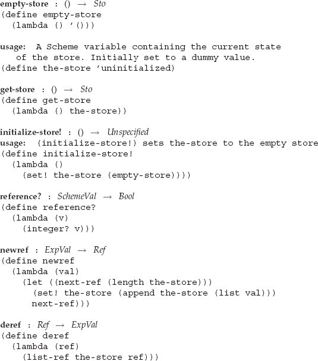

**Figure 4.1** A naive model of the store

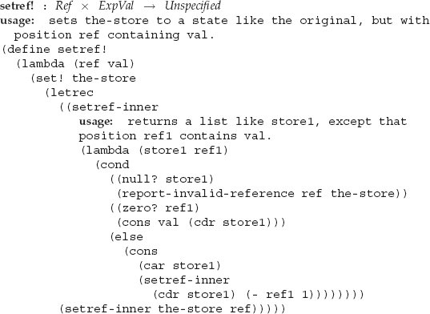

**Figure 4.2** A naive model of the store, continued

Exercise 4.8 [⋆] Show exactly where in our implementation of the store these operations take linear time rather than constant time.

Exercise 4.9 [⋆] Implement the store in constant time by representing it as a Scheme vector. What is lost by using this representation?

Exercise 4.10 [⋆] Implement the begin expression as specified in exercise 4.4.

Exercise 4.11 [⋆] Implement list from exercise 4.5.

Exercise 4.12 [⋆⋆⋆] Our understanding of the store, as expressed in this interpreter, depends on the meaning of effects in Scheme. In particular, it depends on us knowing *when* these effects take place in a Scheme program. We can avoid this dependency by writing an interpreter that more closely mimics the specification. In this interpreter, value-of would return both a value and a store, just as in the specification. A fragment of this interpreter appears in figure 4.6. We call this a *store-passing interpreter*. Extend this interpreter to cover all of the language EXPLICIT-REFS.

Every procedure that might modify the store returns not just its usual value but also a new store. These are packaged in a data type called answer. Complete this definition of value-of.

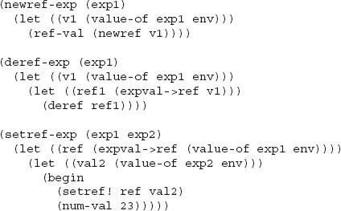

**Figure 4.3** value-of clauses for explicit-reference operators

Exercise 4.13 [⋆⋆⋆] Extend the interpreter of the preceding exercise to have procedures of multiple arguments.

**4.3 IMPLICIT-REFS: A Language with Implicit References**

The explicit reference design gives a clear account of allocation, dereferencing, and mutation because all these operations are explicit in the programmer’s code.

Most programming languages take common patterns of allocation, dereferencing, and mutation, and package them up as part of the language. Then the programmer need not worry about when to perform these operations, because they are built into the language.

In this design, every variable denotes a reference. Denoted values are references to locations that contain expressed values. References are no longer expressed values. They exist only as the bindings of variables.

| *ExpVal* | = | *Int* + *Bool*+ *Proc* |
| --- | --- | --- |
| *DenVal* | = | *Ref*(*ExpVal*) |

Locations are created with each binding operation: at each procedure call, let, or letrec.

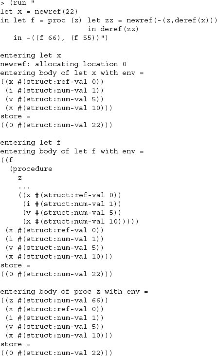

**Figure 4.4** Trace of an evaluation in EXPLICIT-REFS.

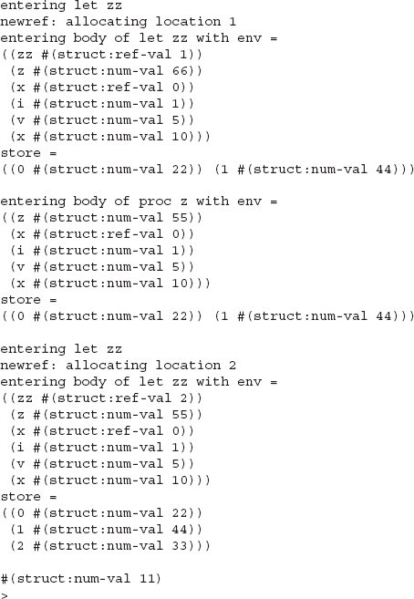

**Figure 4.5** Trace of an evaluation in EXPLICIT-REFS, continued

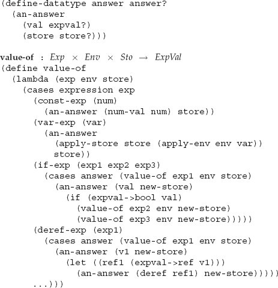

**Figure 4.6** Store-passing interpreter for exercise 4.12

When a variable appears in an expression, we first look up the identifier in the environment to find the location to which it is bound, and then we look up in the store to find the value at that location. Hence we have a “two-level” system for var-exp.

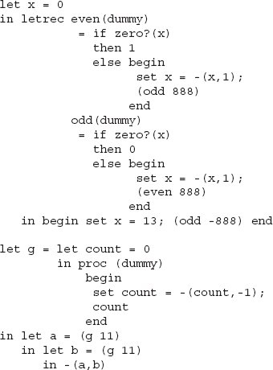

**Figure 4.7** odd and even in IMPLICIT-REFS

This design is called *call-by-value*, or *implicit references*. Most programming languages, including Scheme, use some variation on this design.

Figure 4.7 has our two sample programs in this design. Because references are no longer expressed values, we can’t make chains of references, as we did in the last example in section 4.2.

**4.3.1 Specification**

We can write the rules for dereference and set easily. The environment now always binds variables to locations, so when a variable appears as an expression, we need to dereference it:

(value-of (var-exp *var*) *ρ* *σ*) = (*σ*(*ρ*(*var*)),*σ*)

Assignment works as one might expect: we look up the left-hand side in the environment, getting a location, we evaluate the right-hand side in the environment, and we modify the desired location. As with setref, the value returned by a set expression is arbitrary. We choose to have it return the expressed value 27.

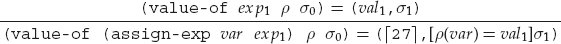

We also need to rewrite the rules for procedure call and let to show the modified store. For procedure call, the rule becomes

(apply-procedure (procedure *var body* *ρ*) *val σ*)

= (value-of *body* [*var* = *l*]*ρ* [*l* = *val*]*σ*)

where *l* is a location not in the domain of *σ*.

The rule for (let-exp *var exp*<sub>1</sub> *body*) is similar. The right-hand side *exp*<sub>1</sub> is evaluated, and the value of the let expression is the value of the body, evaluated in an environment where the variable *var* is bound to a new location containing the value of *exp*<sub>1</sub>.

Exercise 4.14 [⋆] Write the rule for let.

**4.3.2 The Implementation**

Now we are ready to modify the interpreter. In value-of, we dereference at each var-exp, just like the rules say

(var-exp (var) (deref (apply-env env var)))

and we write the obvious code for a assign-exp

(assign-exp (var exp1)

(begin

(setref!

(apply-env env var)

(value-of exp1 env))

(num-val 27)))

What about creating references? New locations should be allocated at every new binding. There are exactly four places in the language where new bindings are created: in the initial environment, in a let, in a procedure call, and in a letrec.

In the initial environment, we explicitly allocate new locations.

For let, we change the corresponding line in value-of to allocate a new location containing the value, and to bind the variable to a reference to that location.

(let-exp (var exp1 body)

(let ((val1 (value-of exp1 env)))

(value-of body

(extend-env var (newref val1) env))))

For a procedure call, we similarly change apply-procedure to call newref.

**apply-procedure** : *Proc* × *ExpVal* → *ExpVal*

(define apply-procedure

(lambda (proc1 val)

(cases proc proc1

(procedure (var body saved-env)

(value-of body

(extend-env var (newref val) saved-env))))))

Last, to handle letrec, we replace the extend-env-rec clause in apply-env to return a reference to a location containing the appropriate closure. Since we are using multideclaration letrec (exercise 3.32), extend-env-rec takes a list of procedure names, a list of bound variables, a list of procedure bodies, and a saved environment. The procedure location takes a variable and a list of variables and returns either the position of the variable in the list, or #f if it is not present.

(extend-env-rec (p-names b-vars p-bodies saved-env)

(let ((n (location search-var p-names)))

(if n

(newref

(proc-val

(procedure

(list-ref b-vars n)

(list-ref p-bodies n)

env)))

(apply-env saved-env search-var))))

Figure 4.8 shows a simple evaluation in IMPLICIT-REFS, using the same instrumentation as before.

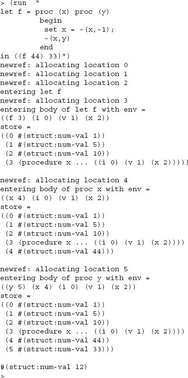

**Figure 4.8** Sample evaluation in IMPLICIT-REFS

Exercise 4.15 [⋆] In figure 4.8, why are variables in the environment bound to plain integers rather than expressed values, as in figure 4.5?

Exercise 4.16 [⋆] Now that variables are mutable, we can build recursive procedures by assignment. For example

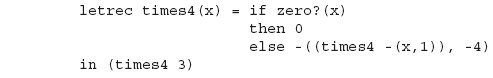

can be replaced by

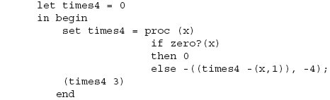

Trace this by hand and verify that this translation works.

Exercise 4.17 [⋆⋆] Write the rules for and implement multiargument procedures and let expressions.

Exercise 4.18 [⋆⋆] Write the rule for and implement multiprocedure letrec expressions.

Exercise 4.19 [⋆⋆] Modify the implementation of multiprocedure letrec so that each closure is built only once, and only one location is allocated for it. This is like exercise 3.35.

Exercise 4.20 [⋆⋆] In the language of this section, all variables are mutable, as they are in Scheme. Another alternative is to allow both mutable and immutable variable bindings:

| *ExpVal* | = | *Int* + *Bool* + *Proc* |
| --- | --- | --- |
| *DenVal* | = | *Ref*(*ExpVal*) + *ExpVal* |

Variable assignment should work only when the variable to be assigned to has a mutable binding. Dereferencing occurs implicitly when the denoted value is a reference.

Modify the language of this section so that let introduces immutable variables, as before, but mutable variables are introduced by a letmutable expression, with syntax given by

*Expression* ::= letmutable *Identifier* = *Expression* in *Expression*

Exercise 4.21 [⋆⋆] We suggested earlier the use of assignment to make a program more modular by allowing one procedure to communicate information to a distant procedure without requiring intermediate procedures to be aware of it. Very often such an assignment should only be temporary, lasting for the execution of a procedure call. Add to the language a facility for *dynamic assignment* (also called *fluid binding*) to accomplish this. Use the production

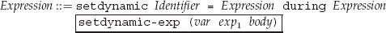

The effect of the setdynamic expression is to assign temporarily the value of *exp*<sub>1</sub> to *var*, evaluate *body*, reassign *var* to its original value, and return the value of *body*. The variable *var* must already be bound. For example, in

let x = 11

in let p = proc (y) -(y,x)

in -(setdynamic x = 17 during (p 22),

(p 13))

the value of x, which is free in procedure p, is 17 in the call (p 22), but is reset to 11 in the call (p 13), so the value of the expression is 5 − 2 = 3.

Exercise 4.22 [⋆⋆] So far our languages have been expression-oriented: the primary syntactic category of interest has been expressions and we have primarily been interested in their values. Extend the language to model the simple statement-oriented language whose specification is sketched below. Be sure to *Follow the Grammar* by writing separate procedures to handle programs, statements, and expressions.

**Values** As in IMPLICIT-REFS.

**Syntax** Use the following syntax:

| *Program* | ::= *Statement* |
| --- | --- |
| *Statement* | ::= *Identifier* = *Expression* |
|  | ::= print *Expression* |
|  | ::= {{*Statement*}<sup>∗(</sup>;) } |
|  | ::= if *Expression Statement Statement* |
|  | ::= while *Expression Statement* |
|  | ::= var {*Identifier*}<sup>∗(</sup>,) ; *Statement* |

The nonterminal *Expression* refers to the language of expressions of IMPLICIT-REFS, perhaps with some extensions.

**Semantics** A program is a statement. A statement does not return a value, but acts by modifying the store and by printing.

Assignment statements work in the usual way. A print statement evaluates its actual parameter and prints the result. The if statement works in the usual way. A block statement, defined in the last production for *Statement*, binds each of the declared variables to an uninitialized reference and then executes the body of the block. The scope of these bindings is the body.

Write the specification for statements using assertions like

(result-of *stmt* *ρ* *σ*<sub>0</sub>) = *σ*<sub>1</sub>

**Examples** Here are some examples.

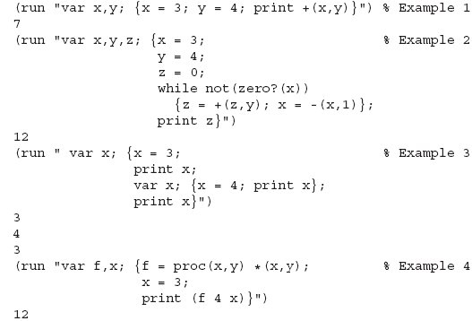

Example 3 illustrates the scoping of the block statement.

Example 4 illustrates the interaction between statements and expressions. A procedure value is created and stored in the variable f. In the last line, this procedure is applied to the actual parameters 4 and x; since x is bound to a reference, it is dereferenced to obtain 3.

Exercise 4.23 [⋆] Add to the language of exercise 4.22 read statements of the form read *var*. This statement reads a nonnegative integer from the input and stores it in the given variable.

Exercise 4.24 [⋆] A do-while statement is like a while statement, except that the test is performed *after* the execution of the body. Add do-while statements to the language of exercise 4.22.

Exercise 4.25 [⋆] Extend the block statement of the language of exercise 4.22 to allow variables to be initialized. In your solution, does the scope of a variable include the initializer for variables declared later in the same block statement?

Exercise 4.26 [⋆⋆⋆] Extend the solution to the preceding exercise so that procedures declared in a single block are mutually recursive. Consider restricting the language so that the variable declarations in a block are followed by the procedure declarations.

Exercise 4.27 [⋆⋆] Extend the language of the preceding exercise to include *subroutines*. In our usage a subroutine is like a procedure, except that it does not return a value and its body is a statement, rather than an expression. Also, add subroutine calls as a new kind of statement and extend the syntax of blocks so that they may be used to declare both procedures and subroutines. How does this affect the denoted and expressed values? What happens if a procedure is referenced in a subroutine call, or vice versa?

**4.4 MUTABLE-PAIRS: A Language with Mutable Pairs**

In exercise 3.9 we added lists to our language, but these were immutable: there was nothing like Scheme’s set-car! or set-cdr! for them.

Now, let’s add mutable pairs to IMPLICIT-REFS. Pairs will be expressed values, and will have the following operations:

| **newpair** | : *Expval* × *Expval* → *MutPair* |
| --- | --- |
| **left** | : *MutPair*→*Expval* |
| **right** | : *MutPair*→*Expval* |
| **setleft** | : *MutPair*×*Expval* → *Unspecified* |
| **setright** | : *MutPair*×*Expval* → *Unspecified* |

A pair consists of two locations, each of which is independently assignable. This gives us the domain equations:

| *ExpVal* | = | *Int* + *Bool*+ *Proc*+ *MutPair* |
| --- | --- | --- |
| *DenVal* | = | *Ref*(*ExpVal*) |
| *MutPair* | = | *Ref*(*ExpVal*) × *Ref*(*ExpVal*) |

We call this language MUTABLE-PAIRS.

**4.4.1 Implementation**

We can implement this literally using the reference data type from our preceding examples. The code is shown in figure 4.9.

Once we’ve done this, it is straightforward to add these to the language. We add a mutpair-val variant to our data type of expressed values, and five new lines to value-of. These are shown in figure 4.10. We arbitrarily choose to make setleft return 82 and setright return 83. The trace of an example, using the same instrumentation as before, is shown in figures 4.11 and 4.12.

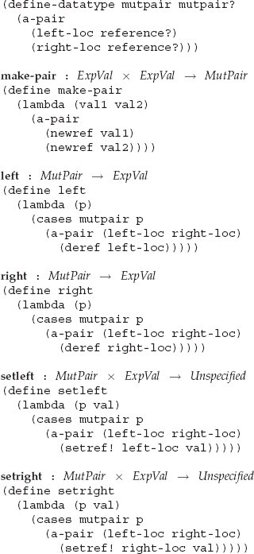

**Figure 4.9** Naive implementation of mutable pairs

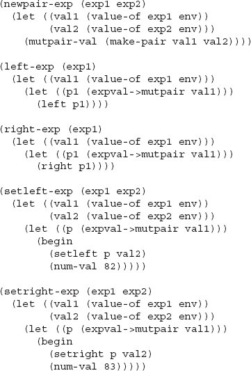

**Figure 4.10** Integrating mutable pairs into the interpreter

**4.4.2 Another Representation of Mutable Pairs**

The representation of a mutable pair as two references does not take advantage of all we know about *MutPair*. The two locations in a pair are independently assignable, but they are not independently allocated. We know that they will be allocated together: if the left part of a pair is one location, then the right part is in the next location. So we can instead represent the pair by a reference to its left. The code for this is shown in figure 4.13. Nothing else need change.

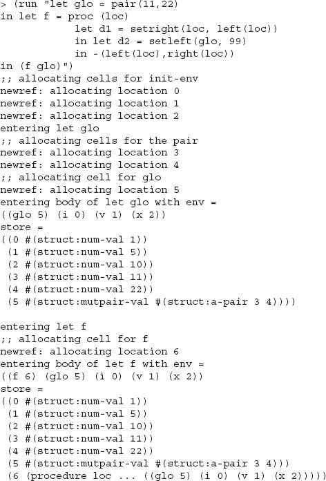

**Figure 4.11** Trace of evaluation in MUTABLE-PAIRS

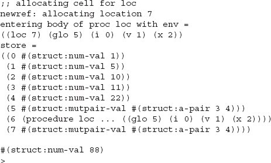

**Figure 4.12** Trace of evaluation in MUTABLE-PAIRS, cont’d

Similarly, one could represent any aggregate object in the heap by a pointer to its first location. However, a pointer does not by itself identify an area of memory unless it is supplemented by information about the length of the area (see exercise 4.30). The lack of length information is a source of classic security errors, such as out-of-bounds array writes.

Exercise 4.28 [⋆⋆] Write down the specification rules for the five mutable-pair operations.

Exercise 4.29 [⋆⋆] Add arrays to this language. Introduce new operators newarray, arrayref, and arrayset that create, dereference, and update arrays. This leads to

| *ArrVal* | = (*Ref*(*ExpVal*))<sup>∗</sup> |
| --- | --- |
| *ExpVal* | = *Int* + *Bool* + *Proc* + *ArrVal* |
| *DenVal* | = *Ref*(*ExpVal*) |

Since the locations in an array are consecutive, use a representation like the second representation above. What should be the result of the following program?

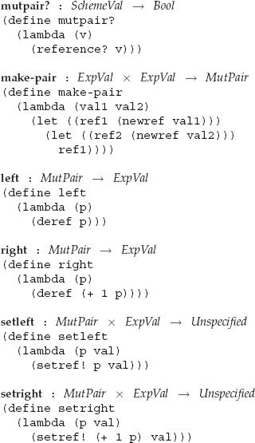

**Figure 4.13** Alternate representation of mutable pairs

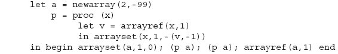

Here newarray(2,-99) is intended to build an array of size 2, with each location in the array containing -99. begin expressions are defined in exercise 4.4. Make the array indices zero-based, so an array of size 2 has indices 0 and 1.

Exercise 4.30 [⋆⋆] Add to the language of exercise 4.29 a procedure arraylength, which returns the size of an array. Your procedure should work in constant time. Make sure that arrayref and arrayset check to make sure that their indices are within the length of the array.

**4.5 Parameter-Passing Variations**

When a procedure body is executed, its formal parameter is bound to a denoted value. Where does that value come from? It must be passed from the actual parameter in the procedure call. We have already seen two ways in which a parameter can be passed:

- Natural parameter passing, in which the denoted value is the same as the expressed value of the actual parameter (page 75).
- Call-by-value, in which the denoted value is a reference to a location containing the expressed value of the actual parameter (section 4.3). This is the most commonly used form of parameter-passing.

In this section, we explore some alternative parameter-passing mechanisms.

**4.5.1 CALL-BY-REFERENCE**

Consider the following expression:

let p = proc (x) set x = 4

in let a = 3

in begin (p a); a end

Under call-by-value, the denoted value associated with x is a reference that initially contains the same value as the reference associated with a, but these references are distinct. Thus the assignment to x has no effect on the contents of a’s reference, so the value of the entire expression is 3.

With call-by-value, when a procedure assigns a new value to one of its parameters, this cannot possibly be seen by its caller. Of course, if the parameter passed to the caller contains a mutable pair, as in section 4.4, then the effect of setleft or setright will be visible to a caller. But the effect of a set is not.

Though this isolation between the caller and callee is generally desirable, there are times when it is valuable to allow a procedure to be passed locations with the expectation that they will be assigned by the procedure. This may be accomplished by passing the procedure a reference to the location of the caller’s variable, rather than the contents of the variable. This parameter-passing mechanism is called *call-by-reference*. If an operand is simply a variable reference, a reference to the variable’s location is passed. The formal parameter of the procedure is then bound to this location. If the operand is some other kind of expression, then the formal parameter is bound to a new location containing the value of the operand, just as in call-by-value. Using call-by-reference in the above example, the assignment of 4 to x has the effect of assigning 4 to a, so the entire expression would return 4, not 3.

When a call-by-reference procedure is called and the actual parameter is a variable, what is passed is the *location* of that variable, rather than the contents of that location, as in call-by-value. For example, consider

let f = proc (x) set x = 44

in let g = proc (y) (f y)

in let z = 55

in begin (g z); z end

When the procedure g is called, y is bound to the location of z, not the contents of that location. Similarly, when f is called, x becomes bound to that same location. So x, y, and z will all be bound to the same location, and the effect of the set x = 44 is to set that location to 44. Hence the value of the entire expression is 44. A trace of the execution of this expression is shown in figures 4.14 and 4.15; in this example, x, y, and z all wind up bound to location 5.

A typical use of call-by-reference is to return multiple values. A procedure can return one value in the normal way and assign others to parameters that are passed by reference. For another sort of example, consider the problem of swapping the values in two variables:

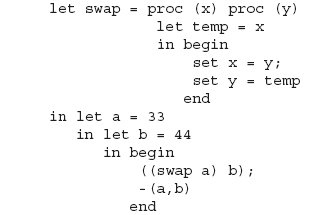

Under call-by-reference, this swaps the values of a and b, so it returns 11. If this program were run with our existing call-by-value interpreter, however, it would return -11, because the assignments inside the swap procedure then have no effect on variables a and b.

Under call-by-reference, variables still denote references to expressed values, just as they did under call-by-value:

| *ExpVal* | = | *Int* + *Bool*+ *Proc* |
| --- | --- | --- |
| *DenVal* | = | *Ref*(*ExpVal*) |

The only thing that changes is the allocation of new locations. Under call-by-value, a new location is created for every evaluation of an operand; under call-by-reference, a new location is created for every evaluation of an operand *other than a variable*.

This is easy to implement. The function apply-procedure must change, because it is no longer true that a new location is allocated for every procedure call. That responsibility must be moved upstream, to the call-exp line in value-of, which will have the information to make that decision.

**apply-procedure** : *Proc* × *Ref* → *ExpVal*

(define apply-procedure

(lambda (proc1 val)

(cases proc proc1

(procedure (var body saved-env)

(value-of body

(extend-env var val saved-env))))))

We then modify the call-exp line in value-of, and introduce a new function value-of-operand that makes the necessary decision.

(call-exp (rator rand)

(let ((proc (expval->proc (value-of rator env)))

(arg (value-of-operand rand env)))

(apply-procedure proc arg)))

The procedure value-of-operand checks to see if the operand is a variable. If it is, then the reference that the variable denotes is returned and then passed to the procedure by apply-procedure. Otherwise, the operand is evaluated, and a reference to a new location containing that value is returned.

**value-of-operand** : *Exp* × *Env* → *Ref*

(define value-of-operand

(lambda (exp env)

(cases expression exp

(var-exp (var) (apply-env env var))

(else

(newref (value-of exp env))))))

We could modify let to work in a similar fashion, but we have chosen not to do so, so that some call-by-value functionality will remain in the language.

More than one call-by-reference parameter may refer to the same location, as in the following program.

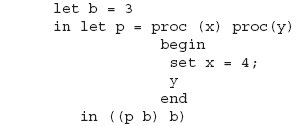

This yields 4 since both x and y refer to the same location, which is the binding of b. This phenomenon is known as *variable aliasing*. Here x and y are aliases (names) for the same location. Generally, we do not expect an assignment to one variable to change the value of another, so aliasing makes it very difficult to understand programs.

Exercise 4.31 [⋆] Write out the specification rules for CALL-BY-REFERENCE.

Exercise 4.32 [⋆] Extend the language CALL-BY-REFERENCE to have procedures of multiple arguments.

Exercise 4.33 [⋆⋆] Extend the language CALL-BY-REFERENCE to support call-by-value procedures as well.

Exercise 4.34 [⋆] Add a call-by-reference version of let, called letref, to the language. Write the specification and implement it.

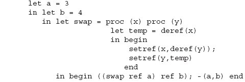

Here we have used a version of let with multiple declarations (exercise 3.16). What are the expressed and denoted values of this language?

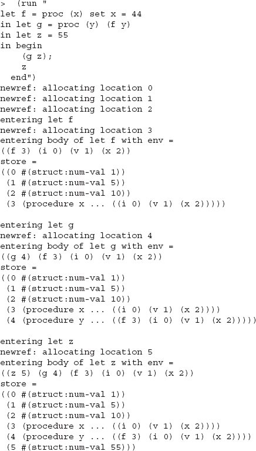

**Figure 4.14** Sample evaluation in CALL-BY-REFERENCE

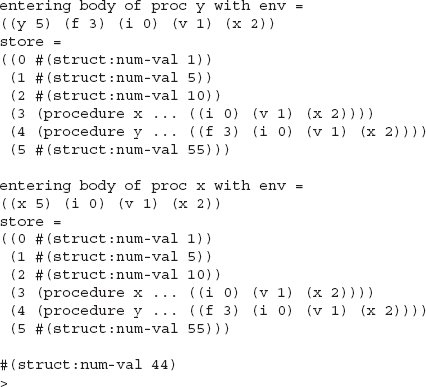

**Figure 4.15** Sample evaluation in CALL-BY-REFERENCE, cont’d

Exercise 4.36 [⋆] Most languages support arrays, in which case array references are generally treated like variable references under call-by-reference. If an operand is an array reference, then the location referred to, rather than its contents, is passed to the called procedure. This allows, for example, a swap procedure to be used in commonly occurring situations in which the values in two array elements are to be exchanged. Add array operators like those of exercise 4.29 to the call-by-reference language of this section, and extend value-of-operand to handle this case, so that, for example, a procedure application like

((swap (arrayref a i)) (arrayref a j))

will work as expected. What should happen in the case of

((swap (arrayref a (arrayref a i))) (arrayref a j)) ?

Exercise 4.37 [⋆⋆] *Call-by-value-result* is a variation on call-by-reference. In call-by-value-result, the actual parameter must be a variable. When a parameter is passed, the formal parameter is bound to a new reference initialized to the value of the actual parameter, just as in call-by-value. The procedure body is then executed normally. When the procedure body returns, however, the value in the new reference is copied back into the reference denoted by the actual parameter. This may be more efficient than call-by-reference because it can improve memory locality. Implement call-by-value-result and write a program that produces different answers using call-by-value-result and call-by-reference.

**4.5.2 Lazy Evaluation: CALL-BY-NAME and CALL-BY-NEED**

All the parameter-passing mechanisms we have discussed so far are *eager*: they always find a value for each operand. We now turn to a very different form of parameter passing, called *lazy evaluation*. Under lazy evaluation, an operand in a procedure call is not evaluated until it is needed by the procedure body. If the body never refers to the parameter, then there is no need to evaluate it.

This can potentially avoid non-termination. For example, consider

letrec infinite-loop (x) = infinite-loop(-(x,-1))

in let f = proc (z) 11

in (f (infinite-loop 0))

We now modify our language to use lazy evaluation. Under lazy evaluation, we do not evaluate an operand expression until it is needed. Therefore we associate the bound variable of a procedure with an unevaluated operand. When the procedure body needs the value of its bound variable, the associated operand is evaluated. We sometimes say that the operand is *frozen* when it is passed unevaluated to the procedure, and that it is *thawed* when the procedure evaluates it.

Of course we will also have to include the environment in which that procedure is to be evaluated. To do this, we introduce a new data type of *thunks*. A thunk consists of an expression and an environment.

(define-datatype thunk thunk?

(a-thunk

(exp1 expression?)

(env environment?)))

When a procedure needs to use the value of its bound variable, it will evaluate the associated thunk.

Our situation is somewhat more complicated, because we need to accommodate both lazy evaluation, effects, and eager evaluation (for let). We therefore let our denoted values be references to locations containing either expressed values or thunks.

| *DenVal* | = | *Ref*(*ExpVal*+ *Thunk*) |
| --- | --- | --- |
| *ExpVal* | = | *Int* + *Bool*+ *Proc* |

Our policy for allocating new locations will be similar to the one we used for call-by-reference: If the operand is a variable, then we pass its denotation, which is a reference. Otherwise, we pass a reference to a new location containing a thunk for the unevaluated argument.

**value-of-operand** : *Exp* × *Env* → *Ref*

(define value-of-operand

(lambda (exp env)

(cases expression exp

(var-exp (var) (apply-env env var))

(else

(newref (a-thunk exp env))))))

When we evaluate a var-exp, we first find the location to which the variable is bound. If the location contains an expressed value, then that value is returned as the value of the var-exp. If it instead contains a thunk, then the thunk is evaluated, and that value is returned. This design is called *call by name*.

(var-exp (var)

(let ((ref1 (apply-env env var)))

(let ((w (deref ref1)))

(if (expval? w)

w

(value-of-thunk w)))))

The procedure value-of-thunk is defined as

**value-of-thunk** : *Thunk* → *ExpVal*

(define value-of-thunk

(lambda (th)

(cases thunk th

(a-thunk (exp1 saved-env)

(value-of exp1 saved-env))))

Alternatively, once we find the value of the thunk, we can install that expressed value in the same location, so that the thunk will not be evaluated again. This arrangement is called *call by need*.

(var-exp (var)

(let ((ref1 (apply-env env var)))

(let ((w (deref ref1)))

(if (expval? w)

w

(let ((val1 (value-of-thunk w)))

(begin

(setref! ref1 val1)

val1))))))

This is an instance of a general strategy called *memoization*.

An attraction of lazy evaluation in all its forms is that in the absence of effects, it supports reasoning about programs in a particularly simple way. The effect of a procedure call can be modeled by replacing the call with the body of the procedure, with every reference to a formal parameter in the body replaced by the corresponding operand. This evaluation strategy is the basis for the lambda calculus, where it is called *β*-*reduction*.

Unfortunately, call-by-name and call-by-need make it difficult to determine the order of evaluation, which in turn is essential to understanding a program with effects. If there are no effects, though, this is not a problem. Thus lazy evaluation is popular in functional programming languages (those with no effects), and rarely found elsewhere.

Exercise 4.38 [⋆] The example below shows a variation of exercise 3.25 that works under call-by-need. Does the original program in exercise 3.25 work under call-by-need? What happens if the program below is run under call-by-value? Why?

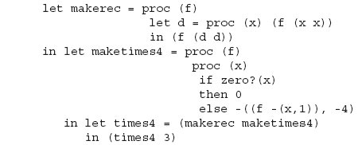

Exercise 4.39 [⋆] In the absence of effects, call-by-name and call-by-need always give the same answer. Construct an example in which call-by-name and call-by-need give different answers.

Exercise 4.40 [⋆] Modify value-of-operand so that it avoids making thunks for constants and procedures.

Exercise 4.41 [⋆⋆] Write out the specification rules for call-by-name and call-by-need.

Exercise 4.42 [⋆⋆] Add a lazy let to the call-by-need interpreter.

**5 *Continuation-Passing Interpreters***

In chapter 3, we used the concept of environments to explore the behavior of bindings, which establish the data context in which each portion of a program is executed. Here we will do the same for the *control context* in which each portion of a program is executed. We will introduce the concept of a *continuation* as an abstraction of the control context, and we will write interpreters that take a continuation as an argument, thus making the control context explicit.

Consider the following definition of the factorial function in Scheme.

(define fact

(lambda (n)

(if (zero? n) 1 (* n (fact (- n 1))))))

We can use a derivation to model a calculation with fact:

|  | (fact 4) |
| --- | --- |
| = | (* 4 (fact 3)) |
| = | (* 4 (* 3 (fact 2))) |
| = | (* 4 (* 3 (* 2 (fact 1)))) |
| = | (* 4 (* 3 (* 2 (* 1 (fact 0))))) = (* 4 (* 3 (* 2 (* 1 1)))) |
| = | (* 4 (* 3 (* 2 1))) |
| = | = (* 4 (* 3 2)) |
| = | (* 4 6) |
| = | 24 |

This is the natural recursive definition of factorial. Each call of fact is made with a promise that the value returned will be multiplied by the value of n at the time of the call. Thus fact is invoked in larger and larger *control contexts* as the calculation proceeds. Compare this behavior to that of the following procedures.

(define fact-iter

(lambda (n)

(fact-iter-acc n 1)))

(define fact-iter-acc

(lambda (n a)

(if (zero? n) a (fact-iter-acc (- n 1) (* n a)))))

With these definitions, we calculate:

|  | (fact-iter 4) |
| --- | --- |
| = | (fact-iter-acc 4 1) |
| = | (fact-iter-acc 3 4) |
| = | (fact-iter-acc 2 12) |
| = | (fact-iter-acc 1 24) |
| = | (fact-iter-acc 0 24) |
| = | 24 |

Here, fact-iter-acc is always invoked in the same control context: in this case, no context at all. When fact-iter-acc calls itself, it does so at the “tail end” of an execution of fact-iter-acc. No promise is made to do anything with the returned value other than to return it as the result of the call to fact-iter-acc. We call this a *tail call*. Thus each step in the derivation above has the form (fact-iter-acc *n a*).

When a procedure such as fact executes, additional control information is recorded with each recursive call, and this information is retained until the call returns. This reflects growth of the control context in the first derivation above. Such a process is said to exhibit *recursive control behavior*.

By contrast, no additional control information need be recorded when fact-iter-acc calls itself. This is reflected in the derivation by recursive calls occurring at the same level within the expression (on the outside in the derivation above). In such cases the system does not need an ever-increasing amount of memory for control contexts as the depth of recursion (the number of recursive calls without corresponding returns) increases. A process that uses a bounded amount of memory for control information is said to exhibit *iterative control behavior*.

Why do these programs exhibit different control behavior? In the recursive definition of factorial, the procedure fact is called *in an operand position*. We need to save context around this call because we need to remember that after the evaluation of the procedure call, we still need to finish evaluating the operands and executing the outer call, in this case to the waiting multiplication. This leads us to an important principle:

**It is evaluation of operands, not the calling of procedures, that makes the control context grow.**

In this chapter we will learn how to track and manipulate control contexts. Our central tool will be the data type of *continuations*. Continuations are an abstraction of the notion of control context, much as environments are an abstraction of data contexts. We will explore continuations by writing an interpreter that explicitly passes a continuation parameter, just as our previous interpreters explicitly passed an environment parameter. Once we do this for the simple cases, we can see how to add to our language facilities that manipulate control contexts in more complicated ways, such as exceptions and threads.

In chapter 6 we show how the same techniques we used to transform the interpreter can be applied to any program. We say that a program transformed in this manner is in *continuation-passing style*. Chapter 6 also shows several other important uses of continuations.

**5.1 A Continuation-Passing Interpreter**

In our new interpreter, the major procedures such as value-of will take a third parameter. This new parameter, the *continuation*, is intended to be an abstraction of the control context in which each expression is evaluated.

We begin with an interpreter in figure 5.1 of the language LETREC of section 3.4. We refer to the result of value-of-program as a *FinalAnswer* to emphasize that this expressed value is the final value of the program.

Our goal is to rewrite the interpreter so that no call to value-of builds control context. When the control context needs to grow, we extend the continuation parameter, much as we extended the environment in the interpreters of chapter 3 as the program builds up data context. By making the control context explicit, we can see how it grows and shrinks, and later, in sections 5.4–5.5 we will use it to add new control behavior to our language.

Now, we know that an environment is a representation of a function from symbols to denoted values. What does a continuation represent? The continuation of an expression represents a procedure that takes the result of the expression and completes the computation. So our interface must include a procedure apply-cont that takes a continuation cont and an expressed value val and finishes the computation as specified by cont. The contract for apply-cont will be

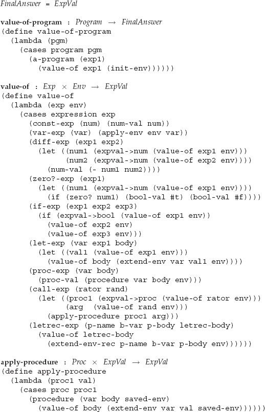

**Figure 5.1** Environment-passing Interpreter

*FinalAnswer* = *ExpVal*

**apply-cont** : *Cont* × *ExpVal* → *FinalAnswer*

We call the result of apply-cont a *FinalAnswer* to remind ourselves that it is the final value of the computation: it will not be used by any other part of our program.

What kind of continuation-builders will be included in the interface? We will discover these continuation-builders as we analyze the interpreter. To begin, we will need a continuation-builder for the context that says there is nothing more to do with the value of the computation. We call this continuation (end-cont), and we will specify it by

(apply-cont (end-cont) *val*)

= (begin

(eopl:printf "End of computation.~%")

*val*)

Invoking (end-cont) prints out an end-of-computation message and returns the value of the program. Because (end-cont) prints out a message, we can tell how many times it has been invoked. In a correct completed computation, it should be invoked exactly once.

We rewrite value-of-program as:

**value-of-program** : *Program* → *FinalAnswer*

(define value-of-program

(lambda (pgm)

(cases program pgm

(a-program (exp1)

(value-of/k exp1 (init-env) (end-cont))))))

We can now begin to write value-of/k. We consider each of the alternatives in value-of in turn. The first few lines of value-of simply calculate a value and return it, without calling value-of again. In the continuation-passing interpreter, these same lines send the same value to the continuation by calling apply-cont:

**value-of/k** : *Exp* × *Env* × *Cont* → *FinalAnswer*

(define value-of/k

(lambda (exp env cont)

(cases expression exp

(const-exp (num) (apply-cont cont (num-val num)))

(var-exp (var) (apply-cont cont (apply-env env var)))

(proc-exp (var body)

(apply-cont cont

(proc-val (procedure var body env))))

...)))

Up to now the only possible value of cont has been the end continuation, but that will change momentarily. It is easy to check that if the program consists of an expression of one of these forms, the value of the expression will be supplied to end-cont (through apply-cont).

The behavior of letrec is almost as simple: it creates a new environment without calling value-of, and then evaluates the body in the new environment. The value of the body becomes the value of the entire expression. That means that the body is performed in the same control context as the entire expression. Therefore the value of the body should be returned to the continuation of the entire expression. Therefore we write

(letrec-exp (p-name b-var p-body letrec-body)

(value-of/k letrec-body

(extend-env-rec p-name b-var p-body env)

cont))

This illustrates a general principle:

**Tail Calls Don’t Grow the Continuation**

*If the value of exp*<sub>1</sub> *is returned as the value of exp*<sub>2</sub>*, then exp*<sub>1</sub> *and exp*<sub>2</sub> *should run in the same continuation.*

It would not be correct to write

(letrec-exp (p-name b-var p-body letrec-body)

(apply-cont cont

(value-of/k letrec-body

(extend-env-rec p-name b-var p-body env)

(end-cont))))

because the call to value-of/k is in an operand position: it appears as an operand to apply-cont. In addition, using the continuation (end-cont) causes the end-of-computation message to be printed before the computation is finished, so an error like this is easy to detect.

Let us next consider a zero? expression. In a zero? expression, we want to evaluate the argument, and then return a value to the continuation depending on the value of the argument. So we evaluate the argument in a new continuation that will look at the returned value and do the right thing.

So in value-of/k we write

(zero?-exp (exp1)

(value-of/k exp1 env

(zero1-cont cont)))

where (zero1-cont cont) is a continuation with the property that

(apply-cont (zero1-cont *cont*) *val*)

= (apply-cont *cont*

(bool-val

(zero? (expval->num *val*))))

Just as with letrec, we could not write in value-of/k

(zero?-exp (exp1)

(let ((val (value-of/k exp1 env (end-cont))))

(apply-cont cont

(bool-val

(zero? (expval->num val))))))

because the call to value-of/k is in operand position. The right-hand side of a let is in operand position, because (let ((*var exp*<sub>1</sub>)) *exp*<sub>2</sub>) is equivalent to ((lambda (*var*) *exp*<sub>2</sub>) *exp*<sub>1</sub>). The value of the call to value-of/k eventually becomes the operand of expval->num. As before, if we ran this code, the end-of-computation message would appear twice: once in the middle of the computation and once at the real end.

A let expression is just slightly more complicated than a zero? expression: after evaluating the right-hand side, we evaluate the body in a suitably extended environment. The original code for let was

(let-exp (var exp1 body)

(let ((val1 (value-of exp1 env)))

(value-of body

(extend-env var val1 env))))

In the continuation-passing interpreter, we need to evaluate exp1 in a context that will finish the computation. So in value-of/k we write

(let-exp (var exp1 body)

(value-of/k exp1 env

(let-exp-cont var body env cont)))

and we add to our continuations interface the specification

(apply-cont (let-exp-cont *var body env cont*) *val*)

= (value-of/k *body* (extend-env *var val env*) *cont*)

The value of the body of the let expression becomes the value of the let expression, so the body of the let expression is evaluated in the same continuation as the entire let expression. This is another instance of the Tail Calls Don’t Grow the Continuation principle.

Let us move on to if expressions. In an if expression, the first thing evaluated is the test, but the result of the test is not the value of the entire expression. We need to build a new continuation that will see if the result of the test expression is a true value, and evaluate either the true expression or the false expression. So in value-of/k we write

(if-exp (exp1 exp2 exp3)

(value-of/k exp1 env

(if-test-cont exp2 exp3 env cont)))

where if-test-cont is a new continuation-builder subject to the specification

(apply-cont (if-test-cont *exp2 exp3 env cont*) *val*)

= (if (expval->bool *val*)

(value-of/k *exp2 env cont*)

(value-of/k *exp3 env cont*))

So far, we have four continuation-builders. We can implement them using either a procedural representation or a data structure representation. The procedural representation is in figure 5.2 and the data structure representation, using define-datatype, is in figure 5.3.

Here is a sample calculation that shows how these pieces fit together. As we did in section 3.3, we write «*exp*» to denote the abstract syntax tree associated with the expression *exp*. Assume *ρ*<sub>0</sub> is an environment in which b is bound to (bool-val #t) and assume *cont*<sub>0</sub> is the initial continuation, which is the value of (end-cont). The commentary is informal and should be checked against the definition of value-of/k and the specification of apply-cont. This example is contrived because we have letrec to introduce procedures but we do not yet have a way to invoke them.

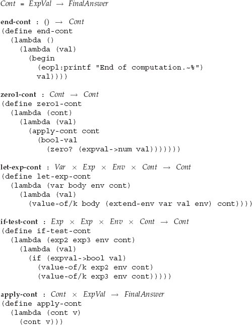

**Figure 5.2** Procedural representation of continuations

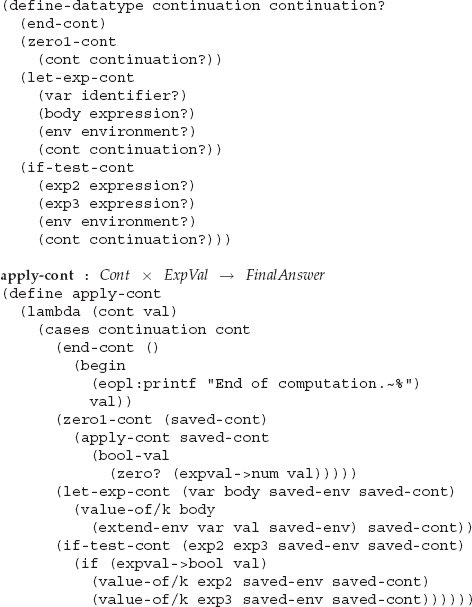

**Figure 5.3** Data structure representation of continuations

(value-of/k <<letrec p(x) = x in if b then 3 else 4>>

*ρ*<sub>0</sub> *cont*<sub>0</sub>)

= *letting* *ρ*<sub>1</sub> *be* (extend-env-rec … *ρ*<sub>0</sub>)

(value-of/k <<if b then 3 else 4>> *ρ*<sub>1</sub> *cont*<sub>0</sub>)

= *next, evaluate the test expression*

(value-of/k <<b>> *ρ*<sub>1</sub> (test-cont <<3>> <<4>> *ρ*<sub>1</sub> *cont*<sub>0</sub>))

= *send the value of* b *to the continuation*

(apply-cont (test-cont <<3>> <<4>> *ρ*<sub>1</sub> *cont*<sub>0</sub>)

(bool-val #t))

= *evaluate the then-expression*

(value-of/k <<3>> *ρ*<sub>1</sub> *cont*<sub>0</sub>)

= *send the value of the expression to the continuation*

(apply-cont *cont*<sub>0</sub> (num-val 3))

= *invoke the final continuation with the final answer*

(begin (eopl:printf …) (num-val 3))

Difference expressions add a new wrinkle to our interpreter because they must evaluate both operands. We begin as we did with if, evaluating the first argument:

(diff-exp (exp1 exp2)

(value-of/k exp1 env

(diff1-cont exp2 env cont)))

When (diff1-cont exp2 env cont) receives a value, it should evaluate exp2 in a context that saves the value of exp1. We specify this by writing

(apply-cont (diff1-cont *exp2 env cont*) *val1*)

= (value-of/k *exp2 env*

(diff2-cont *val1 cont*))

When a (diff2-cont val1 cont) receives a value, we know the values of both operands so we can proceed to send their difference to cont, which has been waiting to receive it. The specification is

(apply-cont (diff2-cont *val1 cont*) *val2*)

= (let ((num1 (expval->num *val1*))

(num2 (expval->num *val2*)))

(apply-cont *cont*

(num-val (- num1 num2))))

Let’s watch this system do an example.

(value-of/k

<<-(-(44,11),3)>>

*ρ*<sub>0</sub>

#(struct:end-cont))

= *start working on first operand*

(value-of/k

<<-(44,11)>>

*ρ*<sub>0</sub>

#(struct:diff1-cont <<3>> *ρ*<sub>0</sub>

#(struct:end-cont)))

= *start working on first operand*

(value-of/k

<<44>>

*ρ*<sub>0</sub>

#(struct:diff1-cont <<11>> *ρ*<sub>0</sub>

#(struct:diff1-cont <<3>> *ρ*<sub>0</sub>

#(struct:end-cont))))

= *send value of <<44>> to continuation*

(apply-cont

#(struct:diff1-cont <<11>> *ρ*<sub>0</sub>

#(struct:diff1-cont <<3>> *ρ*<sub>0</sub>

#(struct:end-cont)))

(num-val 44))

= *now start working on second operand*

(value-of/k

<<11>>

*ρ*<sub>0</sub>

#(struct:diff2-cont (num-val 44)

#(struct:diff1-cont <<3>> *ρ*<sub>0</sub>

#(struct:end-cont))))

= *send value to continuation*

(apply-cont

#(struct:diff2-cont (num-val 44)

#(struct:diff1-cont <<3>> *ρ*<sub>0</sub>

#(struct:end-cont)))

(num-val 11))

= 44 − 11 *is* 33*, send that to the continuation*

(apply-cont

#(struct:diff1-cont <<3>> *ρ*<sub>0</sub>

#(struct:end-cont))

(num-val 33))

= *start working on second operand <<3>>*

(value-of/k

<<3>>

*ρ*<sub>0</sub>

#(struct:diff2-cont (num-val 33)

#(struct:end-cont)))

= *send value to continuation*

(apply-cont

#(struct:diff2-cont (num-val 33)

#(struct:end-cont))

(num-val 3))

= 33 − 3 *is* 30*, send that to the continuation*

(apply-cont

#(struct:end-cont)

(num-val 30))

apply-cont prints out the completion message "End of computation" and returns (num-val 30) as the final answer of the computation.

The last thing in our language is procedure application. In the environment-passing interpreter, we wrote

(call-exp (rator rand)

(let ((proc1 (expval->proc (value-of rator env)))

(val (value-of rand env)))

(apply-procedure proc1 val)))

Here we have two calls to consider, as we did in diff-exp. So we must choose one of them to be first, and then we must transform the remainder to handle the second. Furthermore, we will have to pass the continuation to apply-procedure, because apply-procedure contains a call to value-of/k.

We choose the evaluation of the operator to be first, so in value-of/k we write

(call-exp (rator rand)

(value-of/k rator env

(rator-cont rand env cont)))

As with diff-exp, a rator-cont will evaluate the operand in a suitable continuation:

(apply-cont (rator-cont *rand env cont*) *val1*)

= (value-of/k *rand env*

(rand-cont *val1 cont*))

When a rand-cont receives a value, it is ready to call the procedure:

(apply-cont (rand-cont *val1 cont*) *val2*)

= (let ((proc1 (expval->proc *val1*)))

(apply-procedure/k proc1 *val2 cont*))

Last, we must modify apply-procedure to fit in this continuation-passing style:

**apply-procedure/k** : *Proc* × *ExpVal* × *Cont* → *FinalAnswer*

(define apply-procedure/k

(lambda (proc1 val cont)

(cases proc proc1

(procedure (var body saved-env)

(value-of/k body

(extend-env var val saved-env)

cont)))))

This completes the presentation of the continuation-passing interpreter. The complete interpreter is shown in figures 5.4 and 5.5. The complete specification of the continuations is shown in figure 5.6.

Now we can check the assertion that it is evaluation of actual parameters, not the calling of procedures, that requires growing the control context. In particular, if we evaluate a procedure call (*exp*<sub>1</sub> *exp*<sub>2</sub>) in some continuation *cont*<sub>1</sub>, the body of the procedure to which *exp*<sub>1</sub> evaluates will also be evaluated in the continuation *cont*<sub>1</sub>.

But procedure calls do not themselves grow control contexts. Consider the evaluation of (*exp*<sub>1</sub> *exp*<sub>2</sub>), where the value of *exp*<sub>1</sub> is some procedure *proc*<sub>1</sub> and the value of *exp*<sub>2</sub> is some expressed value *val*<sub>2</sub>.

(value-of/k <<(*exp*<sub>1</sub> *exp*<sub>2</sub>)>> *ρ*<sub>1</sub> *cont*<sub>1</sub>)

= *evaluate operator*

(value-of/k <<*exp*<sub>1</sub>>> *ρ*<sub>1</sub>

(rator-cont <<*exp*<sub>2</sub>>> *ρ*<sub>1</sub> *cont*<sub>1</sub>))

= *send the procedure to the continuation*

(apply-cont

(rator-cont <<*exp*<sub>2</sub>>> *ρ*<sub>1</sub> *cont*<sub>1</sub>)

*proc*<sub>1</sub>)

= *evaluate the operand*

(value-of/k <<*exp*<sub>2</sub>>> *ρ*<sub>1</sub>

(rand-cont *proc*<sub>1</sub> *cont*<sub>1</sub>))

= *send the argument to the continuation*

(apply-cont

(rand-cont *proc*<sub>1</sub> *cont*<sub>1</sub>)

*val*<sub>2</sub>)

= *apply the procedure*

(apply-procedure/k *proc*<sub>1</sub> *val*<sub>2</sub> *cont*<sub>1</sub>)

So the procedure is applied, and its body is evaluated, in the same continuation in which it was called. It is the evaluation of operands, not the entry into a procedure body, that requires control context.

Exercise 5.1 [⋆] Implement this data type of continuations using the procedural representation.

Exercise 5.2 [⋆] Implement this data type of continuations using a data-structure representation.

Exercise 5.3 [⋆] Add let2 to this interpreter. A let2 expression is like a let expression, except that it defines exactly two variables.

Exercise 5.4 [⋆] Add let3 to this interpreter. A let3 expression is like a let expression, except that it defines exactly three variables.

Exercise 5.5 [⋆] Add lists to the language, as in exercise 3.9.

Exercise 5.6 [⋆⋆] Add a list expression to the language, as in exercise 3.10. As a hint, consider adding two new continuation-builders, one for evaluating the first element of the list and one for evaluating the rest of the list.

Exercise 5.7 [⋆⋆] Add multideclaration let (exercise 3.16) to this interpreter.

Exercise 5.8 [⋆⋆] Add multiargument procedures (exercise 3.21) to this interpreter.

Exercise 5.9 [⋆⋆] Modify this interpreter to implement the IMPLICIT-REFS language. As a hint, consider including a new continuation-builder (set-rhs-cont env var cont).

Exercise 5.10 [⋆⋆] Modify the solution to the previous exercise so that the environment is not kept in the continuation.

Exercise 5.11 [⋆⋆] Add the begin expression of exercise 4.4 to the continuation-passing interpreter. Be sure that no call to value-of or value-of-rands occurs in a position that would build control context.

Exercise 5.12 [⋆] Instrument the interpreter of figures 5.4–5.6 to produce output similar to that of the calculation on page 150.

Exercise 5.13 [⋆] Translate the definitions of fact and fact-iter into the LETREC language. You may add a multiplication operator to the language. Then, using the instrumented interpreter of the previous exercise, compute (fact 4) and (fact-iter 4). Compare them to the calculations at the beginning of this chapter. Find (* 4 (* 3 (* 2 (fact 1)))) in the trace of (fact 4). What is the continuation of apply-procedure/k for this call of (fact 1)?

Exercise 5.14 [⋆] The instrumentation of the preceding exercise produces voluminous output. Modify the instrumentation to track instead only the *size* of the largest continuation used during the calculation. We measure the size of a continuation by the number of continuation-builders employed in its construction, so the size of the largest continuation in the calculation on page 150 is 3. Then calculate the values of fact and fact-iter applied to several operands. Confirm that the size of the largest continuation used by fact grows linearly with its argument, but the size of the largest continuation used by fact-iter is a constant.

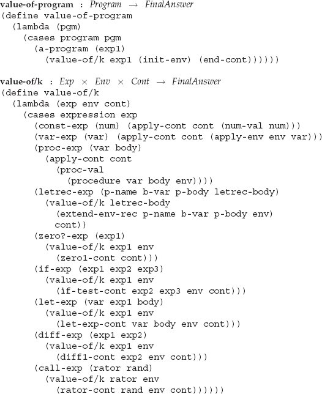

**Figure 5.4** Continuation-passing interpreter (part 1)

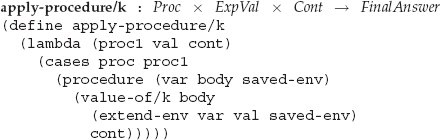

**Figure 5.5** Continuation-passing interpreter (part 2)

Exercise 5.15 [⋆] Our continuation data type contains just the single constant, end-cont, and all the other continuation-builders have a single continuation argument. Implement continuations by representing them as lists, where (end-cont) is represented by the empty list, and each other continuation is represented by a non-empty list whose car contains a distinctive data structure (called *frame* or *activation record*) and whose cdr contains the embedded continuation. Observe that the interpreter treats these lists like a stack (of frames).

Exercise 5.16 [⋆⋆] Extend the continuation-passing interpreter to the language of exercise 4.22. Pass a continuation argument to result-of, and make sure that no call to result-of occurs in a position that grows a control context. Since a statement does not return a value, distinguish between ordinary continuations and continuations for statements; the latter are usually called *command continuations*. The interface should include a procedure apply-command-cont that takes a command continuation and invokes it. Implement command continuations both as data structures and as zero-argument procedures.

**5.2 A Trampolined Interpreter**

One might now be tempted to transcribe the interpreter into an ordinary procedural language, using a data structure representation of continuations to avoid the need for higher-order procedures. Most procedural languages, however, make it difficult to do this translation: instead of growing control context only when necessary, they add to the control context (the stack!) on every procedure call. Since the procedure calls in our system never return until the very end of the computation, the stack in these systems continues to grow until that time.

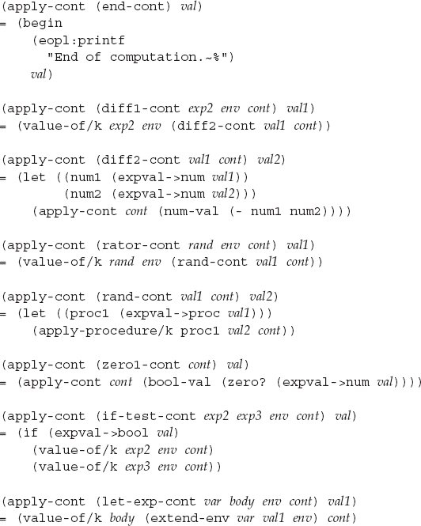

**Figure 5.6** Specification of continuations for figure 5.4

This behavior is not entirely irrational: in such languages almost every procedure call occurs on the right-hand side of an assignment statement, so that almost every procedure call must grow the control context to keep track of the pending assignment. Hence the architecture is optimized for this most common case. Furthermore, most languages store environment information on the stack, so every procedure call must generate a control context that remembers to remove the environment information from the stack.

In such languages, one solution is to use a technique called *trampolining*. To avoid having an unbounded chain of procedure calls, we break the chain by having one of the procedures in the interpreter actually return a zero-argument procedure. This procedure, when called, will continue the computation. The entire computation is driven by a procedure called a *trampoline* that bounces from one procedure call to the next. For example, we can insert a (lambda () …) around the body of apply-procedure/k, since in our language no expression would run more than a bounded amount of time without performing a procedure call.

The resulting code is shown in figure 5.7, which also shows all the tail calls in the interpreter. Since we have modified apply-procedure/k to return a procedure, rather than an *ExpVal*, we must rewrite its contract and also the contracts of all the procedures that call it. We must therefore review the contracts of all the procedures in the interpreter.

We begin with value-of-program. Since this is the procedure that is used to invoke the interpreter, its contract is unchanged. It calls value-of/k and passes the result to trampoline. Since we are now doing something with the result of value-of/k, that result is something other than a *FinalAnswer*. How can that be, since we have not changed the code of value-of/k? The procedure value-of/k calls apply-cont tail-recursively, and apply-cont calls apply-procedure/k tail-recursively, so any result of apply-procedure/k could appear as the result of value-of/k. And, of course, we have modified apply-procedure/k to return something different than it did before.

We introduce the set *Bounce* for the possible results of the value-of/k. (We call it *Bounce* because it is the input to trampoline.) What kind of values could appear in this set? value-of/k calls itself and apply-cont tail-recursively, and these are the only tail-recursive calls it makes. So the only values that could appear as results of value-of/k are those that appear as results of apply-cont. Also, apply-procedure/k calls value-of/k tail-recursively, so whatever *Bounce* is, it is the set of results of value-of/k, apply-cont, and apply-procedure/k.

The procedures value-of/k and apply-cont just call other procedures tail-recursively. The only procedure that actually puts values in *Bounce* is apply-procedure/k. What kind of values are these? Let’s look at the code.

(define apply-procedure/k

(lambda (proc1 val cont)

(lambda ()

(cases procedure proc1

(... (value-of/k …))))))

We see that apply-procedure/k returns a procedure of no arguments, which when called returns either an *ExpVal* or the result of a call to one of value-of/k, apply-cont, or apply-procedure/k, that is, a *Bounce*. So the possible values of apply-procedure/k are described by the set

*ExpVal* ∪ (() → *Bounce*)

These are the same as the possible results of value-of/k, so we conclude that

*Bounce* = *ExpVal* ∪ (() → *Bounce*)

and that the contracts should be

| **value-of-program** : *Program*→*FinalAnswer* |
| --- |
| **trampoline** : *Bounce*→*FinalAnswer* |
| **value-of/k** : *Exp*× *Env* × *Cont* →*Bounce* |
| **apply-cont** : *Cont* × *ExpVal*→*Bounce* |
| **apply-procedure/k** : *Proc* × *ExpVal*× *Cont* →*Bounce* |

The procedure trampoline satisfies its contract: it is initially passed a *Bounce*. If its argument is an *ExpVal* (and hence a *FinalAnswer*), then it returns it. Otherwise the argument must be a procedure that returns a *Bounce*. So it invokes the procedure on no arguments, and calls itself with the resulting value, which will always be a *Bounce*. (We will see in section 7.4 how to automate reasoning like this.)

Each zero-argument procedure returned by apply-procedure/k represents a snapshot of the computation in progress. We could choose to return such a snapshot at different places in the computation; we see in section 5.5 how this idea can be utilized to simulate atomic actions in multithreaded programs.

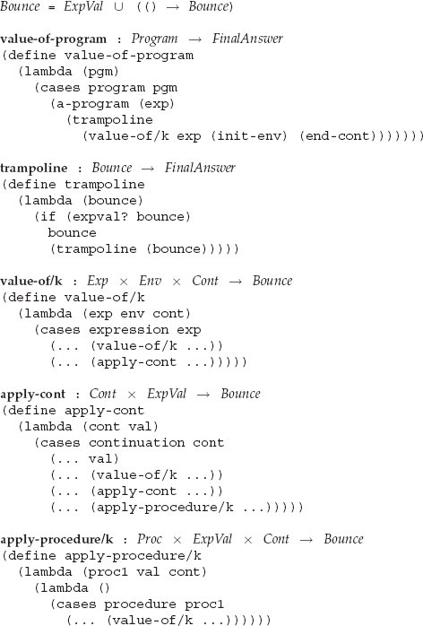

**Figure 5.7** Procedural representation of trampolining

Exercise 5.17 [⋆] Modify the trampolined interpreter to wrap (lambda () …) around each call (there’s only one) to apply-procedure/k. Does this modification require changing the contracts?

Exercise 5.18 [⋆] The trampoline system in figure 5.7 uses a procedural representation of a *Bounce*. Replace this by a data structure representation.

Exercise 5.19 [⋆] Instead of placing the (lambda () …) around the body of apply-procedure/k, place it around the body of apply-cont. Modify the contracts to match this change. Does the definition of *Bounce* need to change? Then replace the procedural representation of *Bounce* with a data-structure representation, as in exercise 5.18.

Exercise 5.20 [⋆] In exercise 5.19, the last bounce before trampoline returns a *FinalAnswer* is always something like (apply-cont (end-cont) *val*), where *val* is some *ExpVal*. Optimize your representation of bounces in exercise 5.19 to take advantage of this fact.

Exercise 5.21 [⋆⋆] Implement a trampolining interpreter in an ordinary procedural language. Use a data structure representation of the snapshots as in exercise 5.18, and replace the recursive call to trampoline in its own body by an ordinary while or other looping construct.

Exercise 5.22 [⋆⋆⋆] One could also attempt to transcribe the environment-passing interpreters of chapter 3 in an ordinary procedural language. Such a transcription would fail in all but the simplest cases, for the same reasons as suggested above. Can the technique of trampolining be used in this situation as well?

**5.3 An Imperative Interpreter**

In chapter 4, we saw how assignment to shared variables could sometimes be used in place of binding. Consider the familiar example of even and odd at the top of figure 5.8. It could be replaced by the program below it in figure 5.8. There the shared variable x allows communication between the two procedures. In the top example, the procedure bodies look for the relevant data in the environment; in the other program, they look for the relevant data in the store.

Consider a trace of the computation at the bottom of figure 5.8. This could be a trace of either computation. It could be a trace of the first computation, in which we keep track of the procedure being called and its argument, or it could be a trace of the second, in which we keep track of the procedure being called and the contents of the register x.

Yet a third interpretation of this trace would be as the trace of *goto*s (called a flowchart program), in which we keep track of the location of the program counter and the contents of the register x.

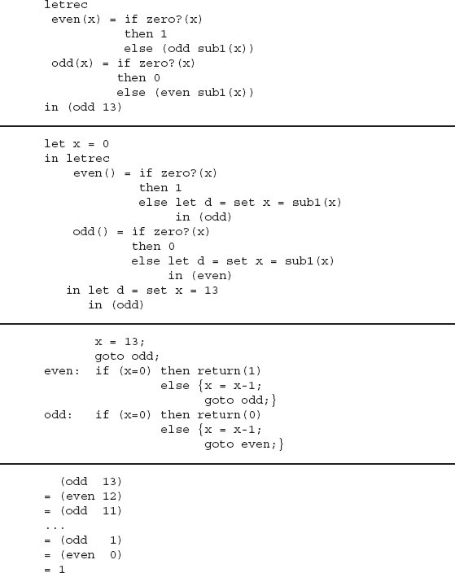

**Figure 5.8** Three programs with a common trace

But this works only because in the original code the calls to even and odd do not grow any control context: they are tail calls. We could not carry out this transformation for fact, because the trace of fact grows unboundedly: the “program counter” appears not at the outside of the trace, as it does here, but inside a control context.

We can carry out this transformation for any procedure that does not require control context. This leads us to an important principle:

**A 0-argument tail call is the same as a jump.**

If a group of procedures call each other only by tail calls, then we can translate the calls to use assignment instead of binding, and then we can translate such an assignment program into a flowchart program, as we did in figure 5.8.

In this section, we will use this principle to translate the continuation-passing interpreter into a form suitable for transcription into a language without higher-order procedures.

We begin with the interpreter of figures 5.4 and 5.5, using a data structure representation of continuations. The data structure representation is shown in figures 5.9 and 5.10.

Our first task is to list the procedures that will communicate via shared registers. These procedures, with their formal parameters, are:

(value-of/k exp env cont)

(apply-cont cont val)

(apply-procedure/k proc1 val cont)

So we will need five global registers: exp, env, cont, val, and proc1. Each of the three procedures above will be replaced by a zero-argument procedure, and each call to one of these procedures will be replaced by code that stores the value of each actual parameter in the corresponding register and then invokes the new zero-argument procedure. So the fragment

(define value-of/k

(lambda (exp env cont)

(cases expression exp

(const-exp (num) (apply-cont cont (num-val num)))

...)))

can be replaced by

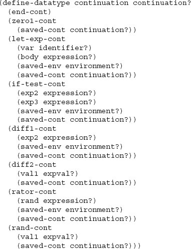

**Figure 5.9** Data structure implementation of continuations (part 1)

(define value-of/k

(lambda ()

(cases expression exp

(const-exp (num)

(set! cont cont)

(set! val (num-val num))

(apply-cont))

...)))

We can now systematically go through each of our four procedures and perform this transformation. We will also have to transform the body of value-of-program, since that is where value-of/k is initially called. There are just three easy-to-resolve complications:

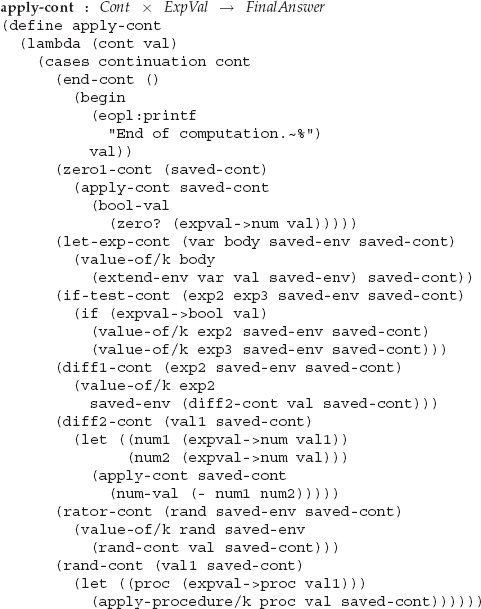

**Figure 5.10** Data structure implementation of continuations (part 2)

1. Often a register is unchanged from one procedure call to another. This yields an assignment like (set! cont cont) in the example above. We can safely omit such assignments.
2. We must make sure that no field name in a cases expression happens to be the same as a register name. In this situation, the field shadows the register, so the register becomes inaccessible. For example, if in value-of-program we had written

   (cases program pgm

   (a-program (exp)

   (value-of/k exp (init-env) (end-cont))))

   then exp would be locally bound, so we could not assign to the global register exp. The solution is to rename the local variable to avoid the conflict:

   (cases program pgm

   (a-program (exp1)

   (value-of/k exp1 (init-env) (end-cont))))

   Then we can write

   (cases program pgm

   (a-program (exp1)

   (set! cont (end-cont))

   (set! exp exp1)

   (set! env (init-env))

   (value-of/k)))

   We have already carefully chosen the field names in our data types to avoid such conflicts.
3. An additional complication may arise if a register is used twice in a single call. Consider transforming a first call in (cons (f (car x)) (f (cdr x))), where x is the formal parameter of f. A naive transformation of this call would be:

   (begin

   (set! x (car x))

   (set! cont (arg1-cont x cont))

   (f))

   But this is incorrect, because it loads the register x with the new value of x, when the old value of x was intended. The solution is either to reorder the assignments so the right values are loaded into the registers, or to use temporary variables. Most occurrences of this bug can be avoided by assigning to the continuation variable first:

   (begin

   (set! cont (arg1-cont x cont))

   (set! x (car x))

   (f))

   Occasionally, temporary variables are unavoidable; consider (f y x) where x and y are the formal parameters of f. Again, this complication does not arise in our example.

The result of performing this translation on our interpreter is shown in figures 5.11–5.14. This process is called *registerization*. It is an easy process to translate this into an imperative language that supports gotos.

Exercise 5.23 [⋆] What happens if you remove the “goto” line in one of the branches of this interpreter? Exactly how does the interpreter fail?

Exercise 5.24 [⋆] Devise examples to illustrate each of the complications mentioned above.

Exercise 5.25 [⋆⋆] Registerize the interpreter for multiargument procedures (exercise 3.21).

Exercise 5.26 [⋆] Convert this interpreter to a trampoline by replacing each call to apply-procedure/k with (set! pc apply-procedure/k) and using a driver that looks like

(define trampoline

(lambda (pc)

(if pc (trampoline (pc)) val)))

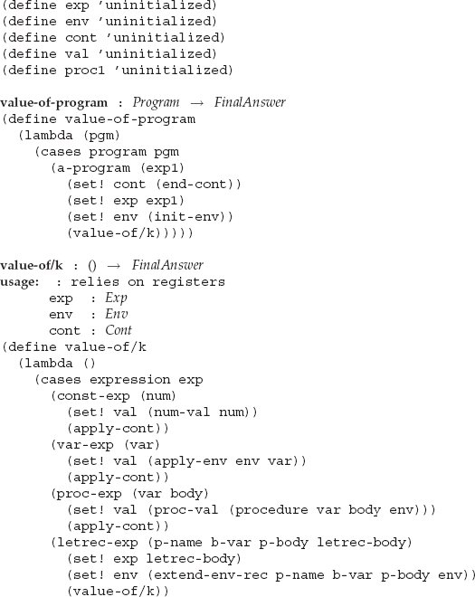

**Figure 5.11** Imperative interpreter (part 1)

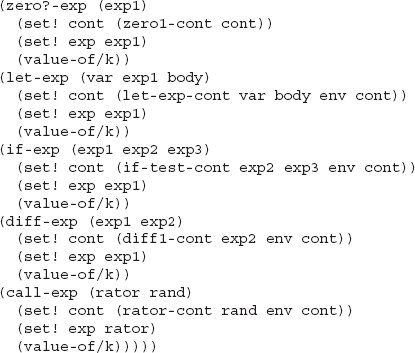

**Figure 5.12** Imperative interpreter (part 2)

Exercise 5.27 [⋆] Invent a language feature for which setting the cont variable last requires a temporary variable.

Exercise 5.28 [⋆] Instrument this interpreter as in exercise 5.12. Since continuations are represented the same way, reuse that code. Verify that the imperative interpreter of this section generates *exactly* the same traces as the interpreter in exercise 5.12.

Exercise 5.29 [⋆] Apply the transformation of this section to fact-iter (page 139).

Exercise 5.30 [⋆⋆] Modify the interpreter of this section so that procedures rely on dynamic binding, as in exercise 3.28. As a hint, consider transforming the interpreter of exercise 3.28 as we did in this chapter; it will differ from the interpreter of this section only for those portions of the original interpreter that are different. Instrument the interpreter as in exercise 5.28. Observe that just as there is only one continuation in the state, there is only one environment that is pushed and popped, and furthermore, it is pushed and popped in parallel with the continuation. We can conclude that dynamic bindings have *dynamic extent*: that is, a binding to a formal parameter lasts exactly until that procedure returns. This is different from lexical bindings, which can persist indefinitely if they wind up in a closure.

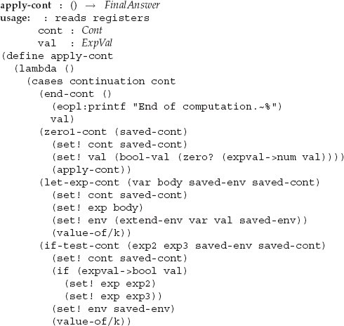

**Figure 5.13** Imperative interpreter (part 3)

Exercise 5.31 [⋆] Eliminate the remaining let expressions in this code by using additional global registers.

Exercise 5.32 [⋆⋆] Improve your solution to the preceding exercise by minimizing the number of global registers used. You can get away with fewer than 5. You may use no data structures other than those already used by the interpreter.

Exercise 5.33 [⋆⋆] Translate the interpreter of this section into an imperative language. Do this twice: once using zero-argument procedure calls in the host language, and once replacing each zero-argument procedure call by a goto. How do these alternatives perform as the computation gets longer?

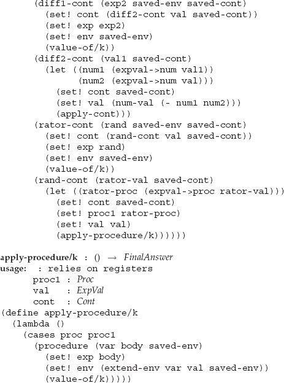

**Figure 5.14** Imperative interpreter (part 4)

Exercise 5.34 [⋆⋆] As noted on page 157, most imperative languages make it difficult to do this translation, because they use the stack for all procedure calls, even tail calls. Furthermore, for large interpreters, the pieces of code linked by goto’s may be too large for some compilers to handle. Translate the interpreter of this section into an imperative language, circumventing this difficulty by using the technique of trampolining, as in exercise 5.26.

**5.4 Exceptions**

So far we have used continuations only to manage the ordinary flow of control in our languages. But continuations allow us to alter the control context as well. Let us consider adding *exception handling* to our defined language. We add to the language two new productions:

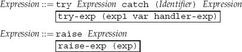

A try expression evaluates its first argument in the context of the exception handler described by the catch clause. If this expression returns normally, its value becomes the value of the entire try expression, and the exception handler is removed.

A raise expression evaluates its single expression and raises an exception with that value. The value is sent to the most recently installed exception handler and is bound to the variable of the handler. The body of the handler is then evaluated. The handler body can either return a value, which becomes the value of the associated try expression, or it can *propagate* the exception by raising another exception; in this case the exception would be sent to the next most recently installed exception handler.

Here’s an example, where we assume for the moment that we have added strings to the language.

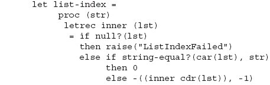

The procedure list-index is a Curried procedure that takes a string and list of strings, and returns the position of the string in the list. If the desired list element is not found, inner raises an exception and passes "ListIndexFailed" to the most recently installed handler, skipping over all the pending subtractions.

The handler can take advantage of knowledge at the call site to handle the exception appropriately.

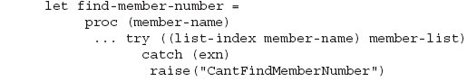

The procedure find-member-number takes a string and uses list-index to find the position of the string in the list member-list. The caller of find-member-number has no reason to know about list-index, so find-member-number translates the error message into an exception that its caller can understand.

Yet another possibility, depending on the purpose of the program, is that find-member-number might return some default number if the member’s name is not in the list.

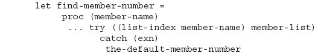

In both these programs, we have ignored the value of the exception. In other situations, the value passed by raise might include some partial information that the caller could utilize.

Implementing this exception-handling mechanism using the continuation-passing interpreter is straightforward. We begin with the try expression. In the data-structure representation, we add two continuation-builders:

(try-cont

(var identifier?)

(handler-exp expression?)

(env environment?)

(cont continuation?))

(raise1-cont

(saved-cont continuation?))

and we add to value-of/k the following clause for try:

(try-exp (exp1 var handler-exp)

(value-of/k exp1 env

(try-cont var handler-exp env cont)))

What happens when the body of the try expression is evaluated? If the body returns normally, then that value should be sent to the continuation of the try expression, in this case cont:

(apply-cont (try-cont *var handler-exp env cont*) *val*)

= (apply-cont *cont val*)

What happens if an exception is raised? First, of course, we need to evaluate the argument to raise.

(raise-exp (exp1)

(value-of/k exp1 env

(raise1-cont cont)))

When the value of exp1 is returned to raise1-cont, we need to search through the continuation for the nearest handler, which may be found in the topmost try-cont continuation. So in the specification of continuations we write

(apply-cont (raise1-cont *cont*) *val*)

= (apply-handler *val cont*)

where apply-handler is a procedure that finds the closest exception handler and applies it (figure 5.15).

To show how all this fits together, let us consider a calculation using a defined language implementation of index. Let *exp*<sub>0</sub> denote the expression

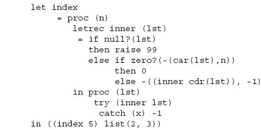

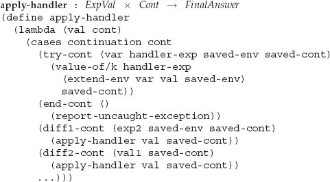

**Figure 5.15** The procedure apply-handler

We start *exp*<sub>0</sub> in an arbitrary environment *ρ*<sub>0</sub> and an arbitrary continuation *cont*<sub>0</sub>. We will show only the highlights of the calculation, with comments interspersed.

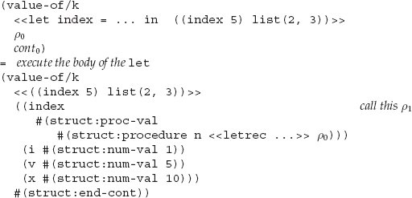

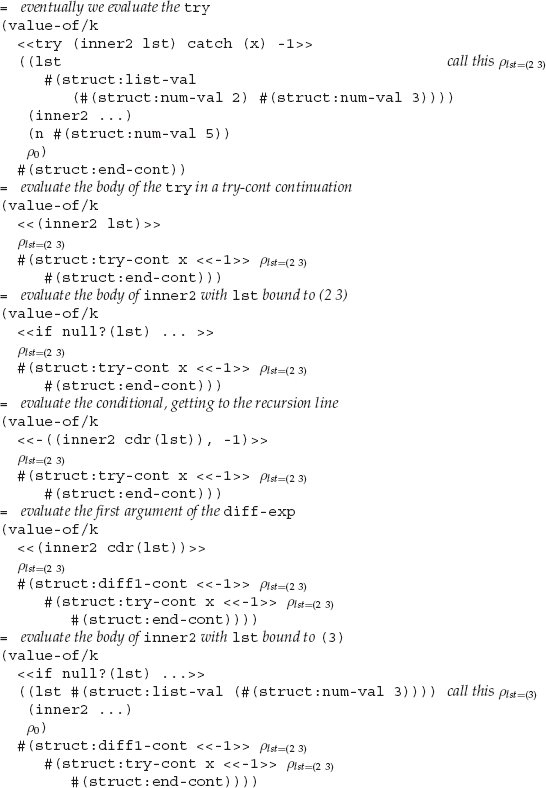

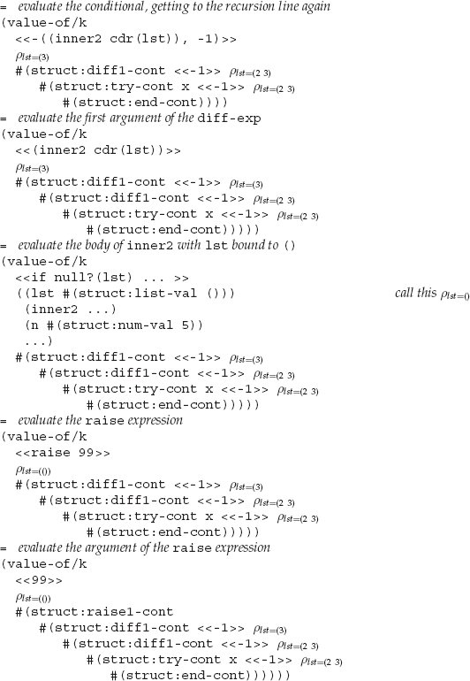

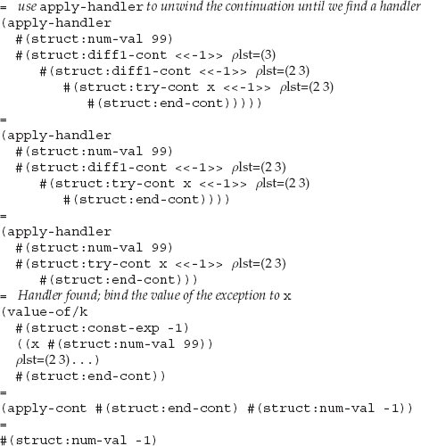

If the list had contained the desired element, then we would have called apply-cont instead of apply-handler, and we would have executed all the pending diffs in the continuation.

Exercise 5.35 [⋆⋆] This implementation is inefficient, because when an exception is raised, apply-handler must search linearly through the continuation to find a handler. Avoid this search by making the try-cont continuation available directly in each continuation.

Exercise 5.36 [⋆] An alternative design that also avoids the linear search in apply-handler is to use two continuations, a normal continuation and an exception continuation. Achieve this goal by modifying the interpreter of this section to take two continuations instead of one.

Exercise 5.37 [⋆] Modify the defined language to raise an exception when a procedure is called with the wrong number of arguments.

Exercise 5.38 [⋆] Modify the defined language to add a division expression. Raise an exception on division by zero.